# Early prediction of student`s outcome in higher education based on demographic, macroeconomic and socioeconomic factors

## 4.9 Investigate variable *Displaced*

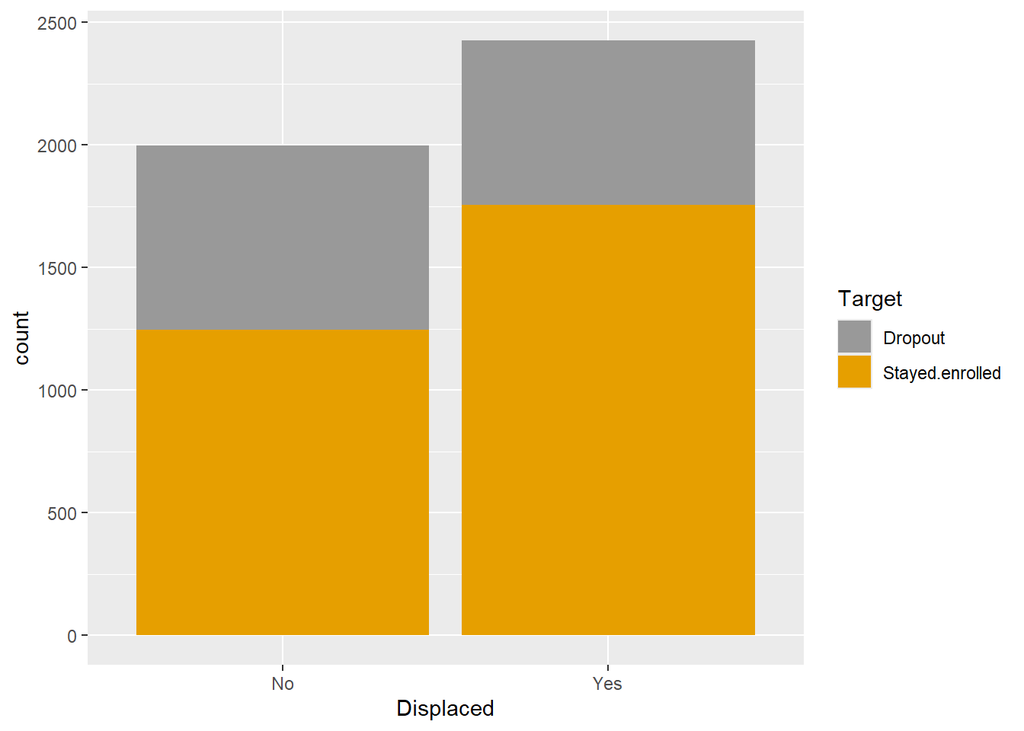

```r
ggplot(data = dropout) +
  geom_bar(aes(x = `Displaced`, fill = `Target`), position = "stack") +
  scale_fill_manual(values = c( "#999999", "#E69F00" ) )
```

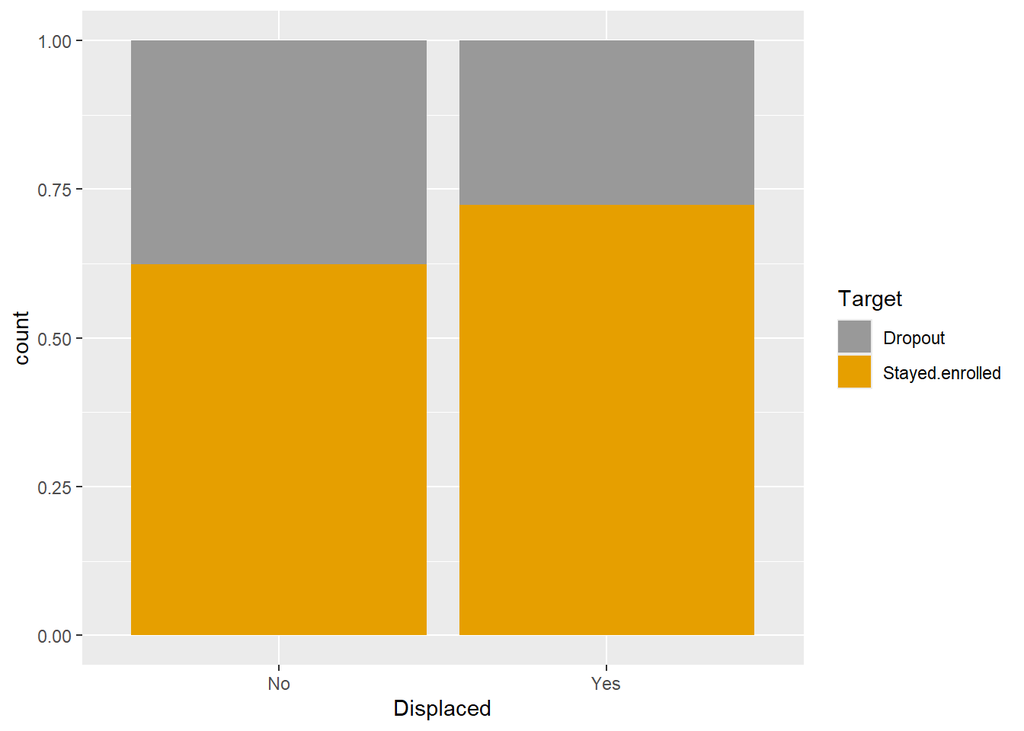

```r
ggplot(data = dropout) +
  geom_bar(aes(x = `Displaced`, fill = `Target`), position = "fill") +
  scale_fill_manual(values = c( "#999999", "#E69F00" ) )
```

Our hypotheses are as follows:

$$\bigg\{
\begin{matrix}
H_0: \pi_{displaced,dropout} = \pi_{(not)displaced,dropout
}, \\
H_a: \pi_{displaced,dropout} \neq \pi_{(not)displaced,dropout }.
\end{matrix}$$

```r
chisq.test( table(dropout $ `Target`, dropout $ `Displaced` ) )
```

```
##
##  Pearson's Chi-squared test with Yates' continuity correction
##
## data:  table(dropout$Target, dropout$Displaced)
## X-squared = 50.41, df = 1, p-value = 1.247e-12
```

Since the p-value (1.247e-12) is less than $\alpha=0.05$, thus we reject the $H_0$. Therefore, the difference of the dropout rate in the proportions of students , who are and are not displaced is statistically significant. This means that the variable `Displaced` is useful to predict the target variable `Target`.

## 4.10 Investigate variable *Educational special needs*

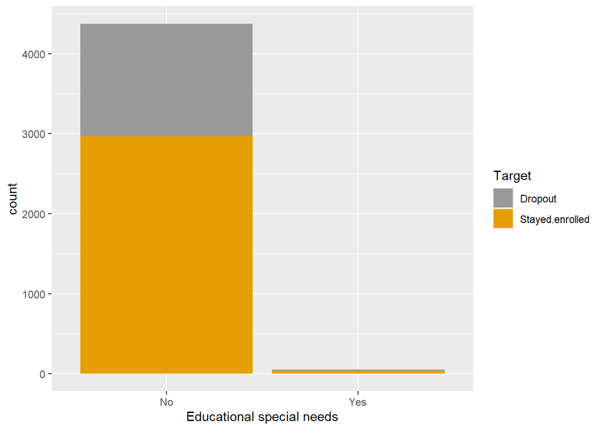

```r
ggplot(data = dropout) +
  geom_bar(aes(x = `Educational special needs`, fill = `Target`), position = "stack") +
  scale_fill_manual(values = c( "#999999", "#E69F00" ) )
```

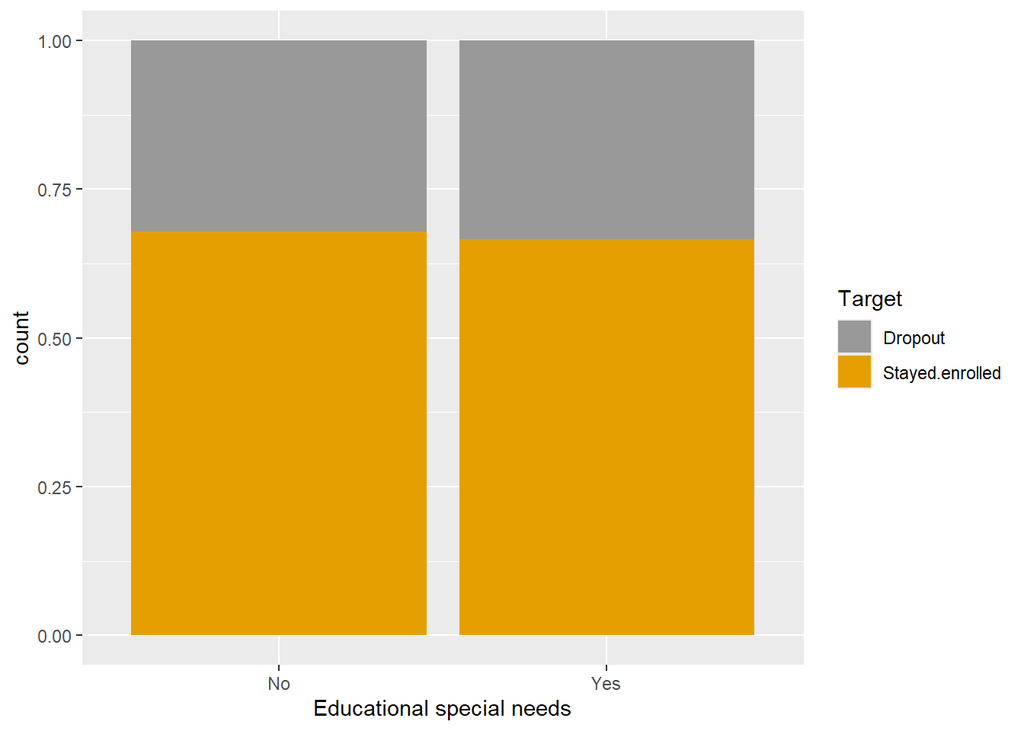

```r
ggplot(data = dropout) +
  geom_bar(aes(x = `Educational special needs`, fill = `Target`), position = "fill") +
  scale_fill_manual(values = c( "#999999", "#E69F00" ) )
```

Form the first bar chart, we can see that the proportion of people with educational needs is insignificant compared to the other proportion, therefore, it will be difficult to derive any conclusions from this relationship. We will conduct a Chi-square hypothesis test with significance level $\alpha=0.05$ to further prove this point.

Our hypotheses are as follows:

$$\bigg\{
\begin{matrix}
H_0: \pi_{educational \ needs, \ dropout} = \pi_{(no)educational
\ needs, \ dropout }, \\
H_a: \pi_{educational \ needs, \ dropout} \neq \pi_{(no)educational
\ needs, \ dropout }.
\end{matrix}$$

```r
chisq.test( table(dropout $ `Target`, dropout $ `Educational special needs` ) )
```

```
##
##  Pearson's Chi-squared test with Yates' continuity correction
##
## data:  table(dropout$Target, dropout$`Educational special needs`)
## X-squared = 0.0012813, df = 1, p-value = 0.9714
```

## 4.11 Investigate variable *Debtor*

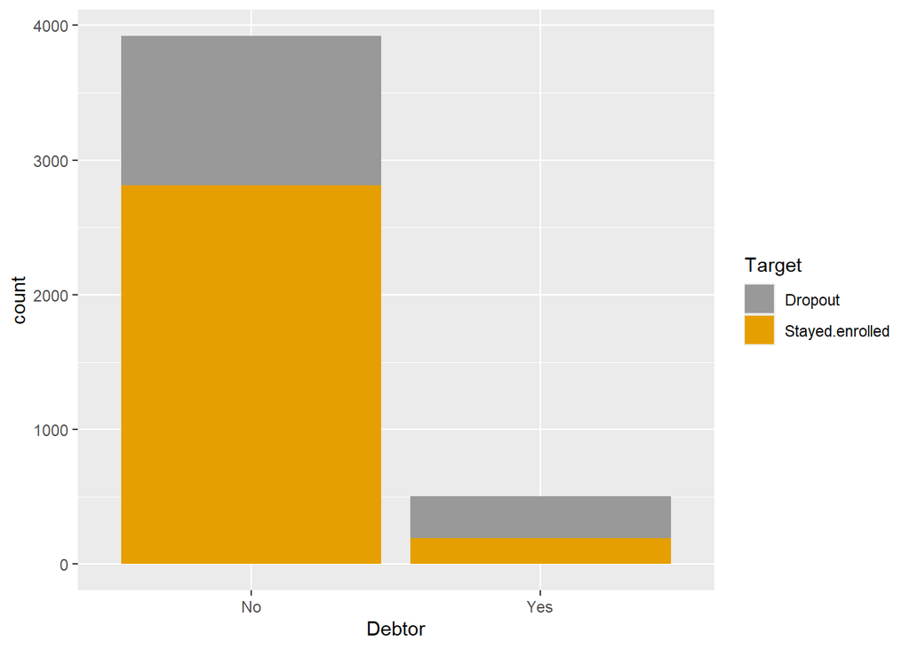

```r
ggplot(data = dropout) +
  geom_bar(aes(x = `Debtor`, fill = `Target`), position = "stack") +
  scale_fill_manual(values = c( "#999999", "#E69F00" ) )
```

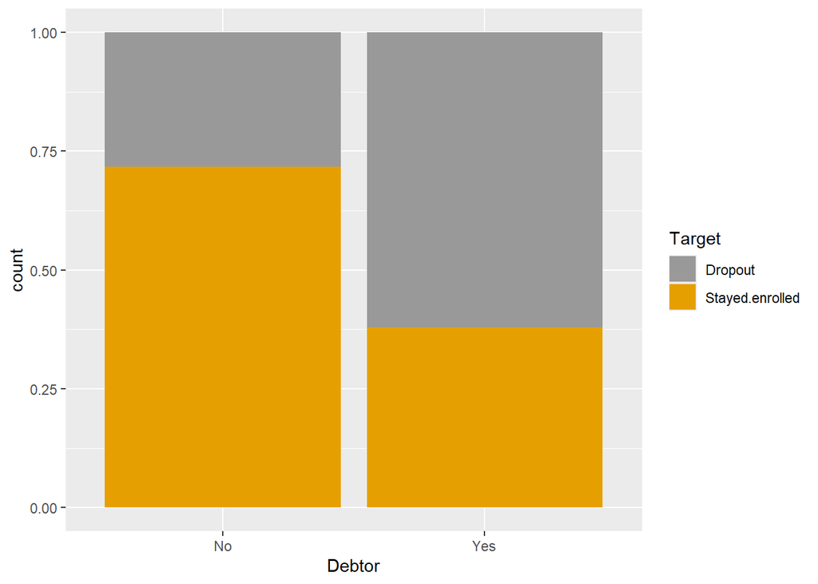

```r
ggplot(data = dropout) +
  geom_bar(aes(x = `Debtor`, fill = `Target`), position = "fill") +
  scale_fill_manual(values = c( "#999999", "#E69F00" ) )
```

Form the first bar chart, we can see that the proportion of students with a debt is a lot smaller than the proportion of students without a debt, therefore, it will be difficult to derive any conclusions from this relationship. However, from the second bar plot, we observe a significant (around 30%) difference in the dropout rate. The students with a debt are more likely to drop out. Therefore, we will conduct a Chi-square hypothesis test with significance level $\alpha=0.05$ to make a conclusion about this relationship.

Our hypotheses are as follows:

$$\bigg\{
\begin{matrix}
H_0: \pi_{debtor,dropout} = \pi_{(not)debtor,dropout }, \\
H_a: \pi_{debtor,dropout} \neq \pi_{(not)debtor,dropout }.
\end{matrix}$$

```r
chisq.test( table(dropout $ `Target`, dropout $ `Debtor` ) )
```

```
##
##  Pearson's Chi-squared test with Yates' continuity correction
##
## data:  table(dropout$Target, dropout$Debtor)
## X-squared = 231.28, df = 1, p-value < 2.2e-16
```

Since the p-value (2.2e-16) is less than $\alpha=0.05$, thus we reject the $H_0$. Therefore, the difference of the dropout rate in the proportions of debtors and non-debtors is statistically significant. This means that the variable `Debtor` is useful to predict the target variable `Target`.

## 4.12 Investigate variable *Tuition fees up to date*

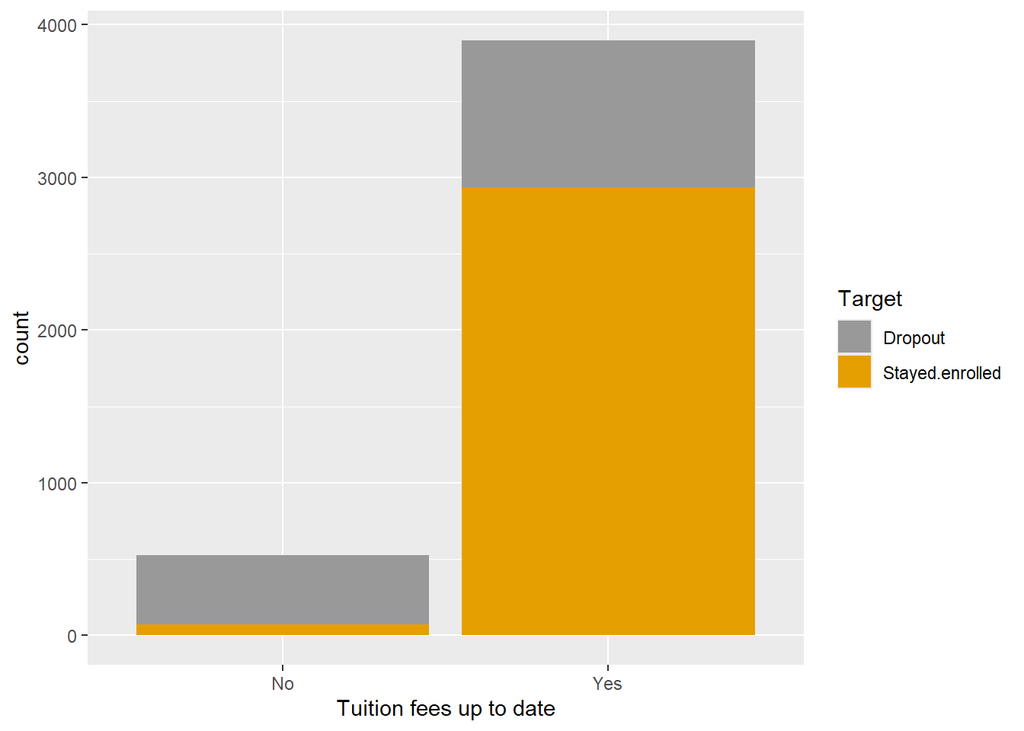

```r
ggplot(data = dropout) +
  geom_bar(aes(x = `Tuition fees up to date`, fill = `Target`), position = "stack") +
  scale_fill_manual(values = c( "#999999", "#E69F00" ) )
```

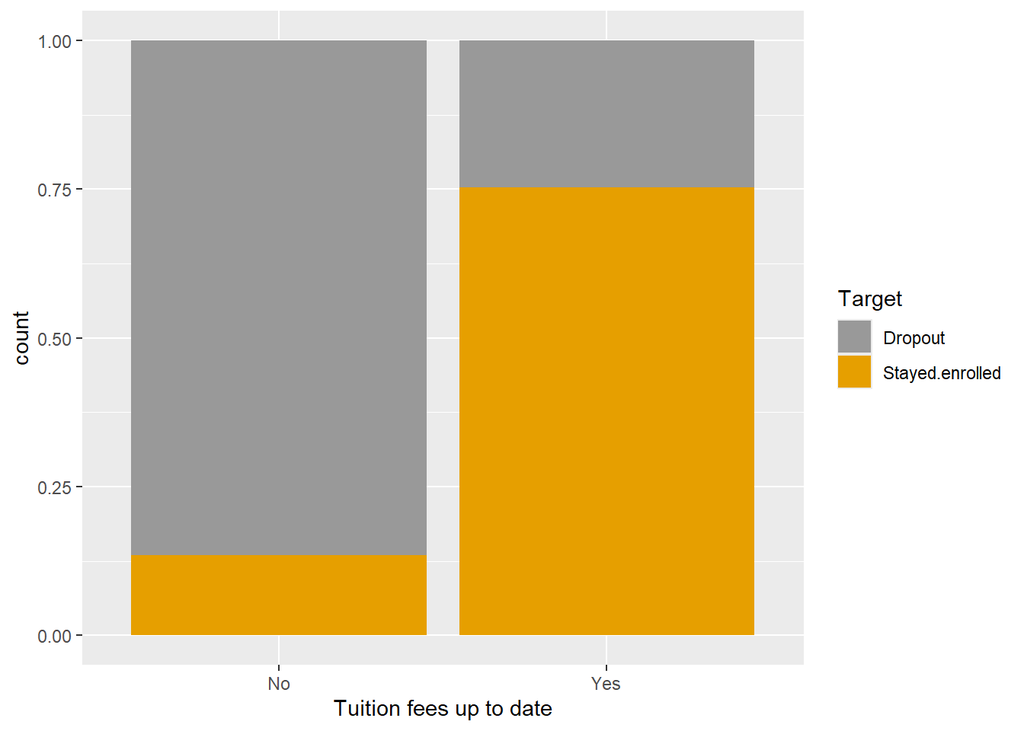

```r
ggplot(data = dropout) +
  geom_bar(aes(x = `Tuition fees up to date`, fill = `Target`), position = "fill") +
  scale_fill_manual(values = c( "#999999", "#E69F00" ) )
```

Form the first bar chart, we can see that the proportion of students with outstanding tuition fees is a lot smaller than the proportion of students with tuition fees up to date , therefore, it will be difficult to derive any conclusions from this relationship. However, from the second bar plot, we observe a significant (around 60%) difference in the dropout rate. Students with tuition fees outstanding are a lot more likely to drop out. Therefore, we will conduct a Chi-square hypothesis test with significance level $\alpha=0.05$ to make a conclusion about this relationship.

Our hypotheses are as follows:

$$\bigg\{
\begin{matrix}
H_0: \pi_{tuitions,dropout} = \pi_{(no)tuitions,dropout }, \\
H_a: \pi_{tuitions,dropout} \neq \pi_{(no)tuitions,dropout }.
\end{matrix}$$

```r
chisq.test( table(dropout $ `Target`, dropout $ `Tuition fees up to date` ) )
```

```
##
##  Pearson's Chi-squared test with Yates' continuity correction
##
## data:  table(dropout$Target, dropout$`Tuition fees up to date`)
## X-squared = 811.93, df = 1, p-value < 2.2e-16
```

Since the p-value (2.2e-16) is less than $\alpha=0.05$, thus we reject the $H_0$. Therefore, the difference in the dropout rate in the proportions of the students, who’s tuition fees are up to date and who’s are not is statistically significant. This means that the variable `Tuition fees up to date` is useful to predict the target variable `Target`.

## 4.13 Investigate variable *Gender*

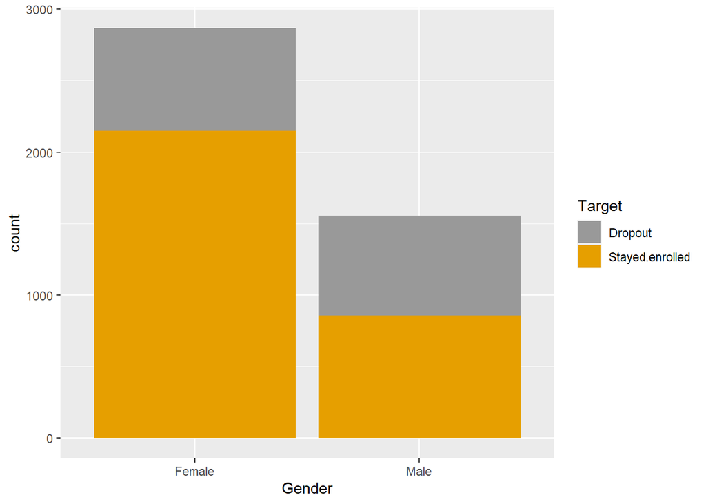

```r
ggplot(data = dropout) +
  geom_bar(aes(x = `Gender`, fill = `Target`), position = "stack") +
  scale_fill_manual(values = c( "#999999", "#E69F00" ) )
```

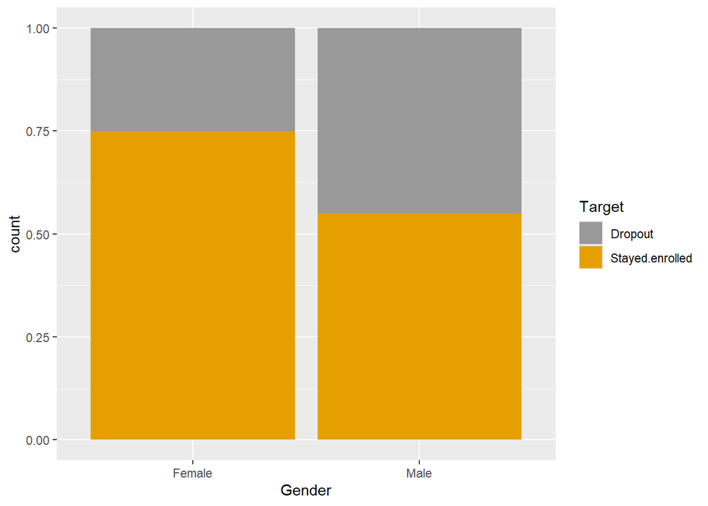

```r
ggplot(data = dropout) +
  geom_bar(aes(x = `Gender`, fill = `Target`), position = "fill") +
  scale_fill_manual(values = c( "#999999", "#E69F00" ) )
```

Our hypotheses are as follows:

$$\bigg\{
\begin{matrix}
H_0: \pi_{male,dropout} = \pi_{female,dropout }, \\
H_a: \pi_{male,dropout} \neq \pi_{female,dropout }.
\end{matrix}$$

```r
chisq.test( table(dropout $ `Target`, dropout $ `Gender` ) )
```

```
##
##  Pearson's Chi-squared test with Yates' continuity correction
##
## data:  table(dropout$Target, dropout$Gender)
## X-squared = 183.16, df = 1, p-value < 2.2e-16
```

Since the p-value (2.2e-16) is less than $\alpha=0.05$, thus we reject the $H_0$. Therefore, the difference in the dropout rate is statistically significant between males and females. This means that the variable `Gender` is useful to predict the target variable `Target`.

## 4.14 Investigate variable *Scholarship holder*

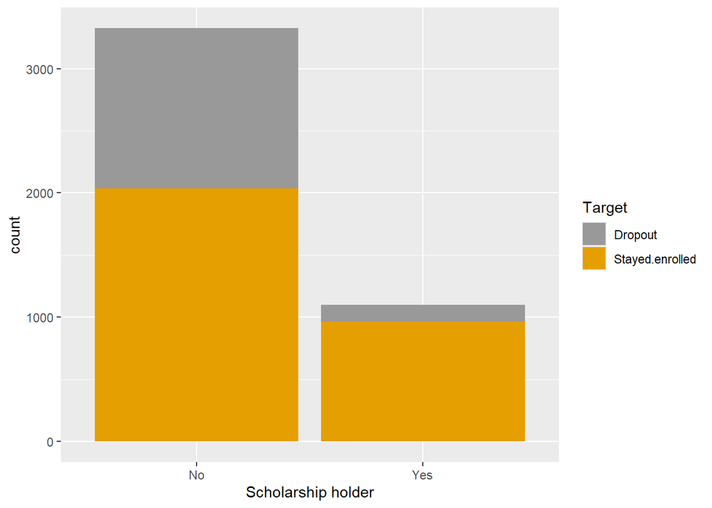

```r
ggplot(data = dropout) +
  geom_bar(aes(x = `Scholarship holder`, fill = `Target`), position = "stack") +
  scale_fill_manual(values = c( "#999999", "#E69F00" ) )
```

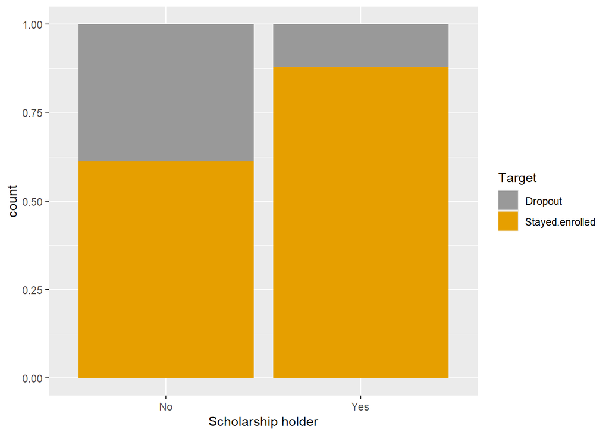

```r
ggplot(data = dropout) +
  geom_bar(aes(x = `Scholarship holder`, fill = `Target`), position = "fill") +
  scale_fill_manual(values = c( "#999999", "#E69F00" ) )
```

From the bar plots above, we can see that although the proportion of the scholarship holders is a lot smaller, there is still about a 25% difference in the dropout proportion within two groups. The dropout rate is a lot lower for scholarship holders, as they are usually more academically successful students that are holding onto the financial aid from the university of the government. We will conduct a Chi-square hypothesis test with significance level $\alpha=0.05$ to further prove our assumption.

Our hypotheses are as follows:

$$\bigg\{
\begin{matrix}
H_0: \pi_{scholarship,dropout} = \pi_{(no)scholarship,dropout
}, \\
H_a: \pi_{scholarship,dropout} \neq \pi_{(no)scholarship,dropout }.
\end{matrix}$$

```r
chisq.test( table(dropout $ `Target`, dropout $ `Scholarship holder` ) )
```

```
##
##  Pearson's Chi-squared test with Yates' continuity correction
##
## data:  table(dropout$Target, dropout$`Scholarship holder`)
## X-squared = 265.1, df = 1, p-value < 2.2e-16
```

Since the p-value (2.2e-16) is less than $\alpha=0.05$, thus we reject the $H_0$. Therefore, the difference in the dropout rate is statistically significant between the scholarship holders and other students. This means that the variable `Scholarship holder` is useful to predict the target variable `Target`.

## 4.15 Investigate variable *Age at enrollment*

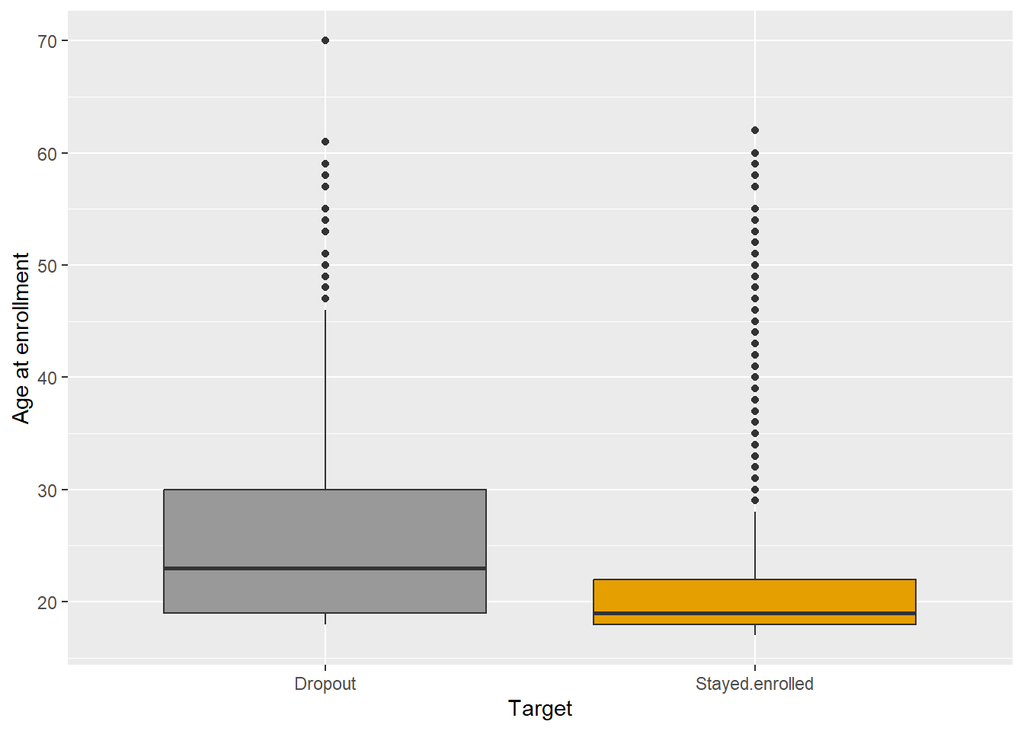

```r
ggplot (data = dropout, aes(x=`Target`, y=`Age at enrollment`), binwidth = 1000, color="white") +
  geom_boxplot(fill= c( "#999999", "#E69F00" ) )
```

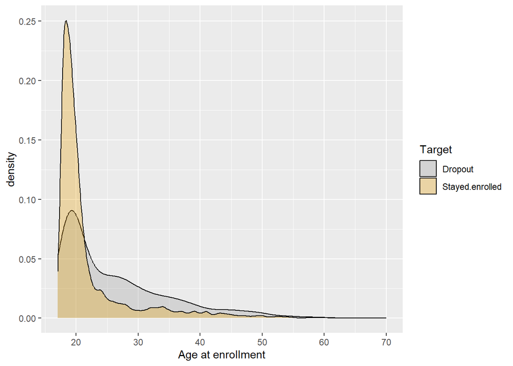

```r
ggplot( data = dropout ) +
  geom_density( aes( x = `Age at enrollment`, fill = `Target`), alpha = 0.3 ) + scale_fill_manual(values = c( "#999999", "#E69F00" ) )
```

From the box plots we learn that the interquartile range for students who dropped out is more than twice as large than for students, who stayed enrolled. Additionally, the median of the group, which dropped out seems to be at a higher age. That means that `Age at enrollment` may be an important factor for predicting `Target`. The density plot confirms the previous statement.

We further test the relationship between `Target` and `Age at enrollment`, we will conduct a Two-Sample T-test fo the difference in means with significance level $\alpha=0.05$.

$$\bigg\{
\begin{matrix}
H_0: \mu_1 = \mu_2, \\
H_a: \mu_1 \neq \mu_2.
\end{matrix}$$

```r
t.test( `Age at enrollment` ~ `Target`, data = dropout )
```

```
##
##  Welch Two Sample t-test
##
## data:  Age at enrollment by Target
## t = 15.863, df = 2219.2, p-value < 2.2e-16
## alternative hypothesis: true difference in means between group Dropout and group Stayed.enrolled is not equal to 0
## 95 percent confidence interval:
##  3.619935 4.641206
## sample estimates:
##         mean in group Dropout mean in group Stayed.enrolled
##                      26.06897                      21.93839
```

Since the p-value (2.2e-16) is less than $\alpha=0.05$, thus we reject the $H_0$. Therefore, the difference in the age of the students, who stayed enrolled and dropped out is statistically significant. This means that the variable `Age at enrollment` is useful to predict the target variable `Target`.

## 4.16 Investigate variable *International*

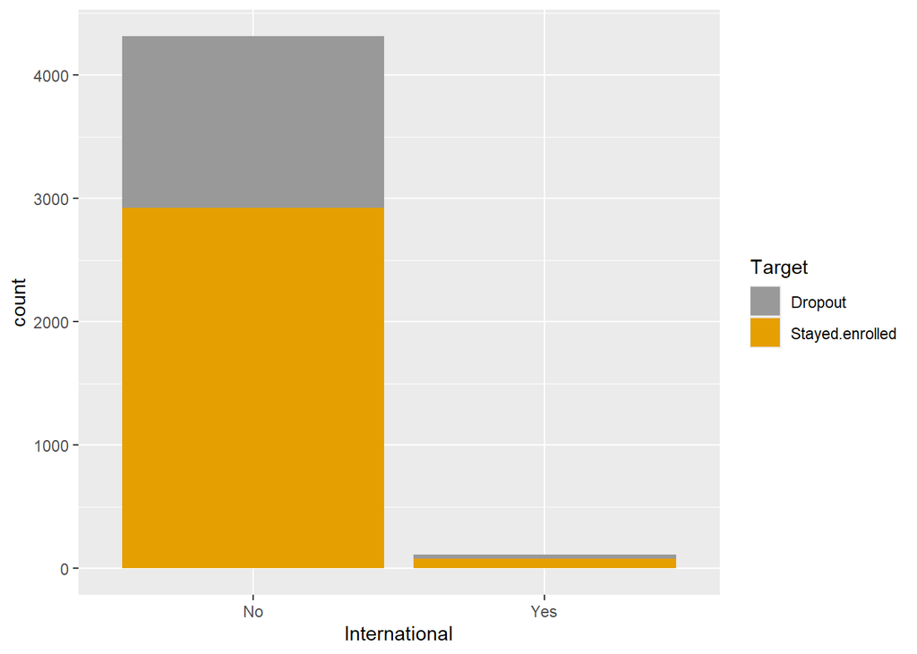

```r
ggplot(data = dropout) +
  geom_bar(aes(x = `International`, fill = `Target`), position = "stack") +
  scale_fill_manual(values = c( "#999999", "#E69F00" ) )
```

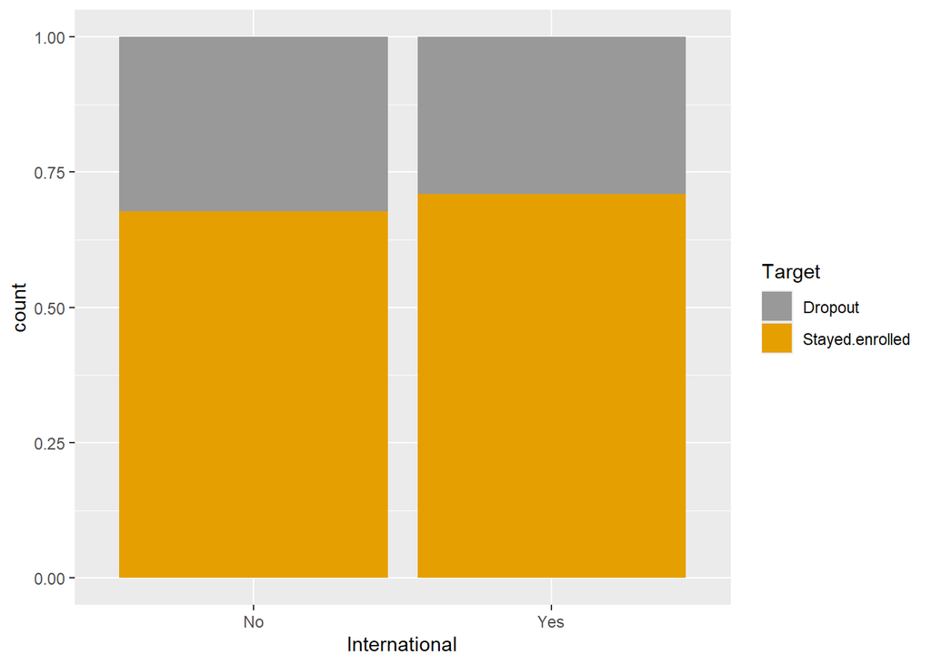

```r
ggplot(data = dropout) +
  geom_bar(aes(x = `International`, fill = `Target`), position = "fill") +
  scale_fill_manual(values = c( "#999999", "#E69F00" ) )
```

```r
table( dropout $ `Target`, dropout $ `International`, dnn = c( "Target", "International" ) )
```

```
##                  International
## Target              No  Yes
##   Dropout         1389   32
##   Stayed.enrolled 2925   78
```

The `dropout` dataset contains information about 4314 students with Portuguese residence and 110 with International residency. It means that only 2.5% of all students came from abroad. From the graphs it is not fully clear if `International` factor makes a big difference on the dropout rate. So we would perform Chi-square hypothesis test with significance level $\alpha=0.05$.

Our hypotheses are:

$$\bigg\{
\begin{matrix}
H_0: \pi_{international,dropout} = \pi_{international,dropout
}, \\
H_a: \pi_{international,dropout} \neq \pi_{international,dropout }.
\end{matrix}$$

```r
chisq.test( table(dropout $ `Target`, dropout $ `International` ) )
```

```
##
##  Pearson's Chi-squared test with Yates' continuity correction
##
## data:  table(dropout$Target, dropout$International)
## X-squared = 0.343, df = 1, p-value = 0.5581
```

Since the p-value equals to 0.5581 which is higher than $\alpha=0.05$, thus we do not reject the $H_0$. Therefore, the difference in the dropout rate is statistically insignificant between international and local students. This means that the variable `International` is not a good predictor of variable `Target`.

## 4.17 Investigate variable *Unemployment rate*

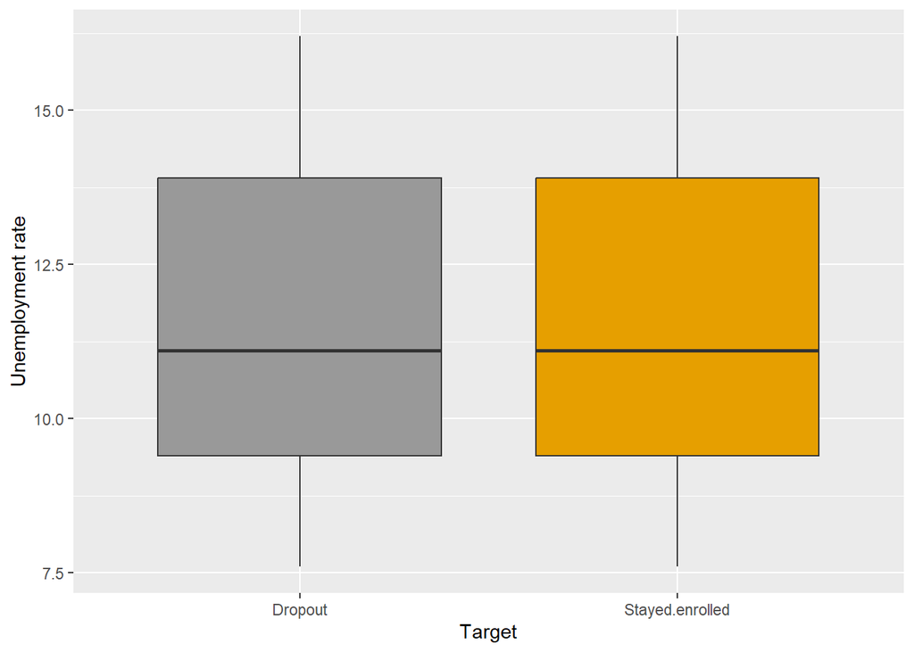

```r
ggplot (data = dropout, aes( x=`Target`, y=`Unemployment rate`)) +
  geom_boxplot(fill= c( "#999999", "#E69F00" ) )
```

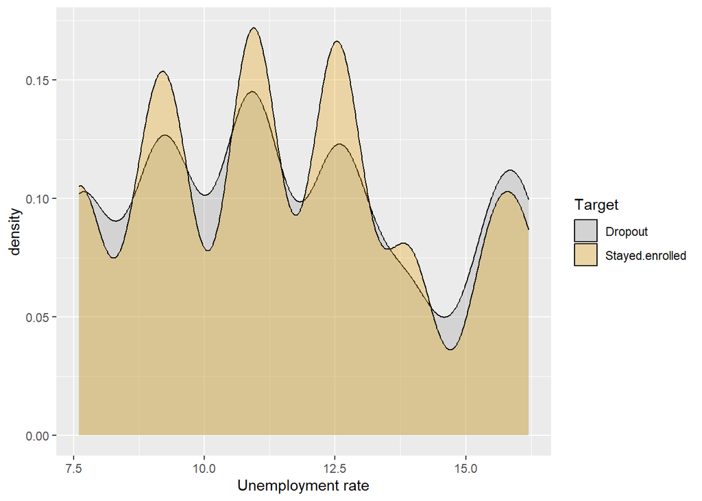

```r
ggplot( data = dropout ) +
  geom_density( aes( x = `Unemployment rate`, fill = `Target`), alpha = 0.3 ) + scale_fill_manual(values = c( "#999999", "#E69F00" ) )
```

We run the two-sample t-test for variables `Unemployment rate` and `Target` to see if there is a relationship between them.

The hypotheses are:

$$\bigg\{
\begin{matrix}
H_0: \mu_{unemployment, \ dropout} = \mu_{unemployment, \
stayed \ enrolled}, \\
H_a: \mu_{unemployment, \ dropout} \neq \mu_{unemployment, \
stayed \ enrolled}.
\end{matrix}$$

```r
t.test( `Unemployment rate` ~ `Target`, data = dropout )
```

```
##
##  Welch Two Sample t-test
##
## data:  Unemployment rate by Target
## t = 0.84558, df = 2647.3, p-value = 0.3979
## alternative hypothesis: true difference in means between group Dropout and group Stayed.enrolled is not equal to 0
## 95 percent confidence interval:
##  -0.09765344  0.24573196
## sample estimates:
##         mean in group Dropout mean in group Stayed.enrolled
##                      11.61640                      11.54236
```

We do not reject the $H_0$, since the p-value (0.3979) is higher than $\alpha=0.05$. Thus, it means there is no statistically significant relationship between the target variable `Target` and `Unemployment`. It indicates that the variable `Unemployment` is not useful for predicting `Target`.

## 4.18 Investigate variable *Inflation rate*

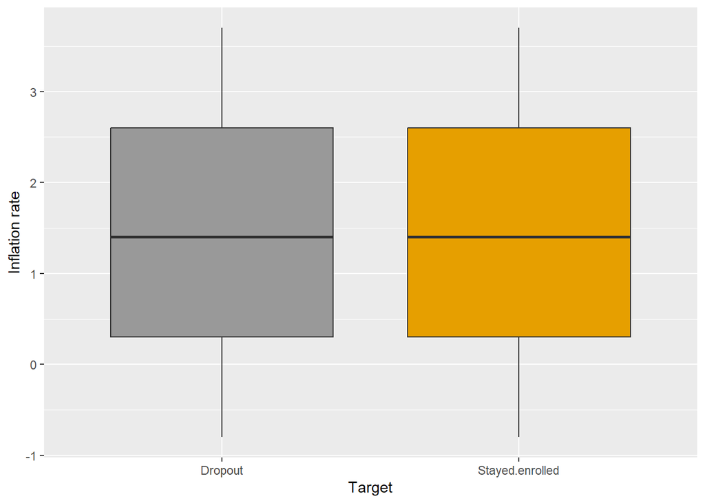

```r
ggplot (data = dropout, aes(x=`Target`, y=`Inflation rate`)) +
  geom_boxplot(fill= c( "#999999", "#E69F00" ) )
```

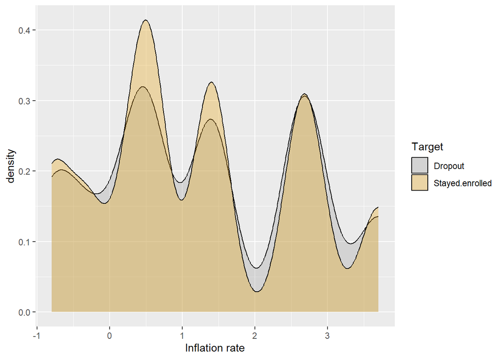

```r
ggplot( data = dropout ) +
  geom_density( aes( x = `Inflation rate`, fill = `Target`), alpha = 0.3 ) + scale_fill_manual(values = c( "#999999", "#E69F00" ) )
```

By just looking at the graphs we cannot conclude if `Inflation rate` factor is a good predictor for `Target` or not. For that we need to run the two-sample t-test for those variables:

Our hypotheses are as follows:

$$\bigg\{
\begin{matrix}
H_0: \mu_{inflation ,\ dropout} = \mu_{inflation ,\ stayed \
enrolled}, \\
H_a: \mu_{inflation ,\ dropout} \neq \mu_{inflation ,\ stayed
\ enrolled}.
\end{matrix}$$

```r
t.test( `Inflation rate` ~ `Target`, data = dropout )
```

```
##
##  Welch Two Sample t-test
##
## data:  Inflation rate by Target
## t = 1.8352, df = 2727, p-value = 0.06658
## alternative hypothesis: true difference in means between group Dropout and group Stayed.enrolled is not equal to 0
## 95 percent confidence interval:
##  -0.005640277  0.170419996
## sample estimates:
##         mean in group Dropout mean in group Stayed.enrolled
##                      1.283955                      1.201565
```

We do not reject the $H_0$, since the p-value (0.06658) is higher than $\alpha=0.05$. Thus, it means there is no statistically significant relationship between the target variable `Target` and `Inflation rate`. It indicates that the variable `Inflation rate` is not useful for predicting `Target`.

## 4.19 Investigate variable *GDP*

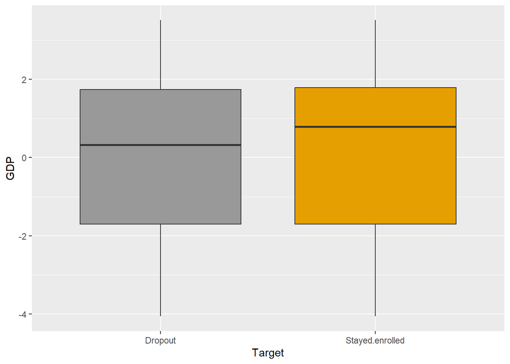

```r
ggplot (data = dropout, aes(x=`Target`, y=`GDP`)) +
  geom_boxplot(fill= c( "#999999", "#E69F00" ) )
```

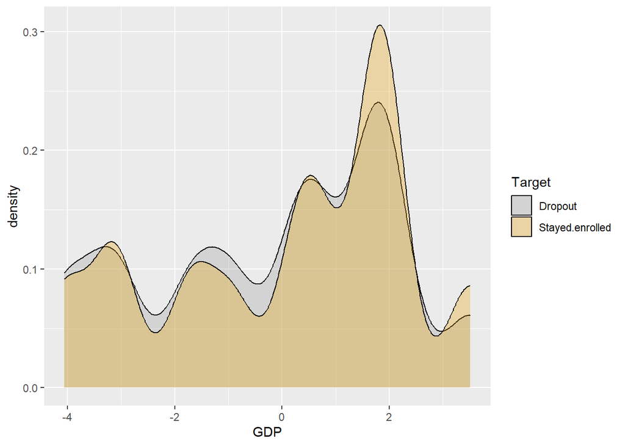

```r
ggplot( data = dropout ) +
  geom_density( aes( x = `GDP`, fill = `Target`), alpha = 0.3 ) + scale_fill_manual(values = c( "#999999", "#E69F00" ) )
```

Looking at above box plots, median rates of the national GDP of the group of people who stayed enrolled is higher than in those students who dropped out. We still want to test if yearly national GDP relates to the dropout rates in universities.

So, the hypotheses are:

$$\bigg\{
\begin{matrix}
H_0: \mu_{GDP ,\ dropout} = \mu_{GDP ,\ stayed \ enrolled},
\\
H_a: \mu_{GDP ,\ dropout} \neq \mu_{GDP ,\ stayed \
enrolled}.
\end{matrix}$$

```r
t.test( `GDP` ~ `Target`, data = dropout )
```

```
##
##  Welch Two Sample t-test
##
## data:  GDP by Target
## t = -3.0949, df = 2813, p-value = 0.001988
## alternative hypothesis: true difference in means between group Dropout and group Stayed.enrolled is not equal to 0
## 95 percent confidence interval:
##  -0.36778734 -0.08250119
## sample estimates:
##         mean in group Dropout mean in group Stayed.enrolled
##                   -0.15085855                    0.07428571
```

We reject the $H_0$, since the p-value is 0.001988 and less than $\alpha=0.05$. True difference in means between dropped out students and students who stayed is not equal to 0. It means there is a statistically significant relationship between the target variable `Target` and `GDP`. It indicates that the variable `GDP` is indeed useful for predicting `Target`. The higher the yearly GDP - the lower the dropout rates in the universities. Maybe it is connected to the fact that during economical downturn more people drop out because can no longer sustain themselves studying in universities.

## 4.20 Detection of Correlated Variables

First, we test categorical variables for correlation. For this we will use the Cramer’s V notation and chi-square test.

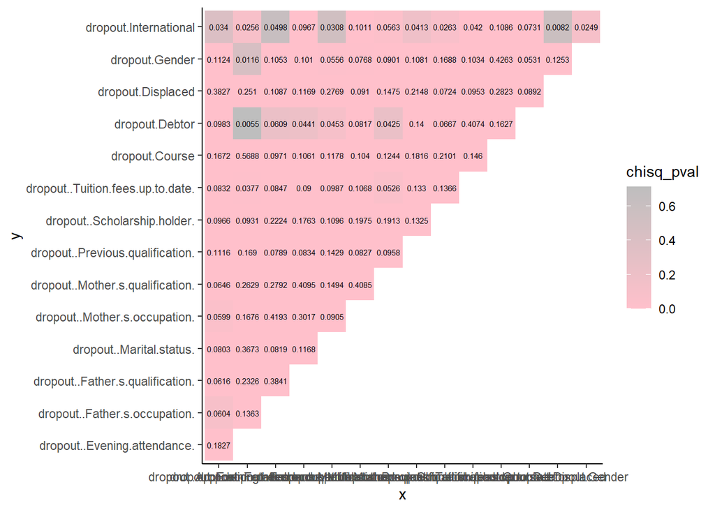

```r
df <- data.frame(dropout$`Marital status`,dropout$Course, dropout$`Previous qualification`,dropout$`Mother's qualification`,dropout$`Mother's occupation`, dropout$`Father's qualification`, dropout$`Father's occupation`, dropout$`Displaced`, dropout$`Debtor`, dropout$`Tuition fees up to date`, dropout$`Gender`, dropout$`Scholarship holder`, dropout$`Application order`, dropout$`Evening attendance`, dropout$`International`)

f = function(x,y) {
    tbl = df %>% select(x,y) %>% table()
    chisq_pval = round(chisq.test(tbl)$p.value, 4)
    cramV = round(cramersV(tbl), 4)
    data.frame(x, y, chisq_pval, cramV) }

df_comb = data.frame(t(combn(sort(names(df)), 2)), stringsAsFactors = F)

df_res = map2_df(df_comb$X1, df_comb$X2, f)

df_res %>%
 ggplot(aes(x,y,fill=chisq_pval))+
  geom_tile()+
  geom_text(aes(x,y,label=cramV), size = 2)+
  scale_fill_gradient(low="pink", high="grey")+
  theme_classic()
```

We do not observe any strong correlations between the categorical variables. The squares in grey represent the Cramer’s V with an insignificant chi-square test.

Secondly, we check numerical variables for correlations with Pearson’s correlation.

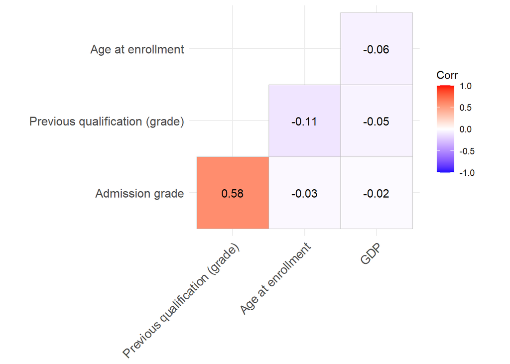

```r
variable_list = c("Admission grade", "Previous qualification (grade)", "Age at enrollment", "GDP")

cor_matrix = cor(dropout[, variable_list])

ggcorrplot(cor_matrix, type = "lower", lab = TRUE)
```

We do not observe any strong correlations, that is why we will keep all of our variables for the classification algorithms.

## 4.21 EDA Resolution

`Marital status`, `Course`, `Previous qualification`,`Mother's qualification`,`Mother's occupation`, `Father's qualification`, `Father's occupation`, `Displaced`, `Debtor`, `Tuition fees up to date`, `Gender`, `Scholarship holder`, `Application order`, `Evening attendance`, `International`, `Admission grade`, `Previous qualification (grade)`, `Age at enrollment`, `GDP`.

# 5 Modeling - Classification

## 5.1 Data preparation

Firstly, we partition the *dropout* dataset into 2 groups: a train set (80%) and test set (20%).

```r
set.seed( 6 )
data_sets = partition( data = dropout, prob = c( 0.8, 0.2 ) )
train_set = data_sets $ part1
test_set  = data_sets $ part2
actual_test  = test_set $ `Target`
```

Secondly, we want to validate the partition with a Two-sample Z-test.

Our hypotheses are as follows:

$$\bigg\{
\begin{matrix}
H_0: \pi_{dropout,train} = \pi_{dropout,test}, \\
H_a: \pi_{dropout,train} \neq \pi_{dropout,test }.
\end{matrix}$$

```r
x1 = sum( train_set $ `Target` == "Stayed.enrolled" )
x2 = sum( test_set  $ `Target`== "Stayed.enrolled" )

n1 = nrow( train_set )
n2 = nrow( test_set  )

prop.test( x = c( x1, x2 ), n = c( n1, n2 ) )
```

```
##
##  2-sample test for equality of proportions with continuity correction
##
## data:  c(x1, x2) out of c(n1, n2)
## X-squared = 1.1518, df = 1, p-value = 0.2832
## alternative hypothesis: two.sided
## 95 percent confidence interval:
##  -0.01577041  0.05459750
## sample estimates:
##    prop 1    prop 2
## 0.6827469 0.6633333
```

Since the p-value equals to 0.2832 which is higher than $\alpha=0.05$, thus we do not reject the $H_0$. Thus, the difference in the proportion of the students who dropped out and stayed enrolled is not statistically significant between the two groups (training set and test set). This implies that the partitioning is valid.

## 5.2 Classification with CART

We create a formula for our further analysis based on the variables that have showed a high predictive power in the previous section.

```r
formula = `Target` ~ `Marital status`+ `Course`+ `Previous qualification`+`Mother's qualification`+`Mother's occupation`+ `Father's qualification`+ `Father's occupation`+ `Displaced`+ `Debtor`+ `Tuition fees up to date`+ `Gender`+ `Scholarship holder`+ `Application order`+ `Evening attendance`+ `International`+ `Admission grade`+ `Previous qualification (grade)`+ `Age at enrollment`+ `GDP`

tree_cart = rpart( formula = formula, data = train_set, method = "class" )

print( tree_cart )
```

```
## n= 3524
##
## node), split, n, loss, yval, (yprob)
##       * denotes terminal node
##
##  1) root 3524 1118 Stayed.enrolled (0.3172531 0.6827469)
##    2) Tuition fees up to date=No 403   58 Dropout (0.8560794 0.1439206) *
##    3) Tuition fees up to date=Yes 3121  773 Stayed.enrolled (0.2476770 0.7523230)
##      6) Age at enrollment>=23.5 791  338 Stayed.enrolled (0.4273072 0.5726928)
##       12) Course=Animation and Multimedia Design,Advertising and Marketing Management,Basic Education,Veterinary Nursing ,Equinculture,Oral Hygiene,Biofuel Production Technologies,Informatics Engineering 204   78 Dropout (0.6176471 0.3823529) *
##       13) Course=Tourism,Communication Design,Journalism and Communication,Social Service,Management,Nursing,Agronomy 587  212 Stayed.enrolled (0.3611584 0.6388416) *
##      7) Age at enrollment< 23.5 2330  435 Stayed.enrolled (0.1866953 0.8133047) *
```

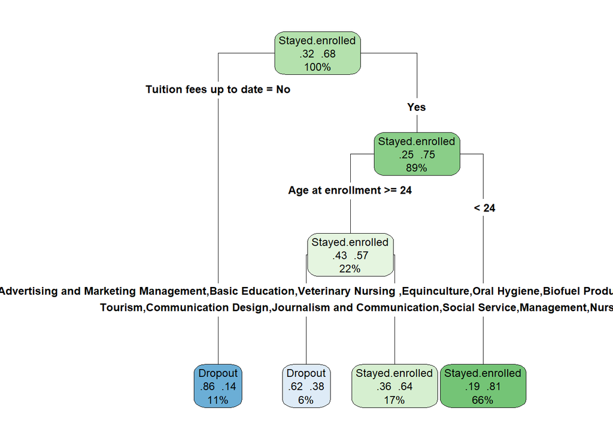

```r
rpart.plot( tree_cart,type = 4, extra = 104)
```

Because of the big amount of categories in on of the variables that the algorithm has chosen for prediction, the tree itself might appear as quite complex, therefore, it is better to orient yourself with the written description of the tree.

In general, the tree indicate that the CART algorithm has chosen 3 predictors(`Tuition fees up to date`, `Age at enrollment` and `Course`). The variable `Tuition fees up to date` is the most important predictor. The tree categorizes students into 4 categories. The highest error rate of the tree is 0.38.

##Classification with C50

We will use the same set of predictors as in the previous section for the C50 algorithm.

```r
tree_C50 = C5.0( formula=formula, data = train_set )
summary(tree_C50)
```

```
##
## Call:
## C5.0.formula(formula = formula, data = train_set)
##
##
## C5.0 [Release 2.07 GPL Edition]      Wed Sep 18 17:10:45 2024
## -------------------------------
##
## Class specified by attribute `outcome'
##
## Read 3524 cases (20 attributes) from undefined.data
##
## Decision tree:
##
## Tuition fees up to date = No:
## :...GDP <= 1.79: Dropout (323/25)
## :   GDP > 1.79:
## :   :...Scholarship holder = Yes: Stayed.enrolled (12/1)
## :       Scholarship holder = No:
## :       :...Evening attendance = Yes: Dropout (8)
## :           Evening attendance = No: [S1]
## Tuition fees up to date = Yes:
## :...Mother's occupation in {Student,Other.or.Blank}:
##     :...Course in {Animation and Multimedia Design,Tourism,
##     :   :          Communication Design,Management,Basic Education,
##     :   :          Equinculture,Oral Hygiene,Agronomy,
##     :   :          Biofuel Production Technologies,
##     :   :          Informatics Engineering}: Dropout (44/1)
##     :   Course in {Journalism and Communication,Social Service,Nursing,
##     :   :          Advertising and Marketing Management,Veterinary Nursing}:
##     :   :...GDP > 0.79: Dropout (6)
##     :       GDP <= 0.79: [S2]
##     Mother's occupation in {Service,Science.Intermediate,Unskilled.Professions,
##     :                       Skilled.Professions,Administrative.Support,
##     :                       Public.Administration,Science.Specialist,
##     :                       Manufacturing,Healthcare,Armed.Forces,Teacher}:
##     :...Scholarship holder = Yes: Stayed.enrolled (838/71)
##         Scholarship holder = No:
##         :...Age at enrollment <= 23: Stayed.enrolled (1526/346)
##             Age at enrollment > 23:
```

[output cut: 144 more lines]

```
##   17.48% Gender
##   15.10% GDP
##    8.23% Application order
##    4.51% Mother's qualification
##    2.55% Previous qualification
##    1.93% Evening attendance
##    1.87% Father's occupation
##    1.50% Admission grade
##    1.36% Displaced
##    0.85% Debtor
##    0.68% Marital status
##    0.57% Previous qualification (grade)
##
##
## Time: 0.0 secs
```

From the summary of the tree, we can conclude that the algorithm has chosen the following variables as primary predictors: `Tuition fees up to date`(main predictor), `GDP`, `Scholarship holder`, `Evening attnedance`, `Mother's occupation`, `Course`, `Age at enrollment`, `Gender`, `Application order`.

## 5.3 Classification with Random Forest

We will use the same set of predictors as in the previous models. At first, we will need to rename our variables for the random forest algorithm to recognize them.

```r
lookup <- c(
 marital.status = "Marital status",
 course= "Course",
 previous.q = "Previous qualification",
 mother.q = "Mother's qualification",
 mother.o = "Mother's occupation",
 father.q  ="Father's qualification",
 father.o = "Father's occupation",
 displaced = "Displaced",
 debtor = "Debtor",
 tuition= "Tuition fees up to date",
 gender = "Gender",
 scholarship = "Scholarship holder",
 application =  "Application order",
 evening.a = "Evening attendance",
 international = "International",
 admission.grade=  "Admission grade",
 previous.q.g ="Previous qualification (grade)",
 age = "Age at enrollment",
 gdp = "GDP"
)
formula1 = `Target`~ marital.status+course+previous.q+mother.q+mother.o+father.q+father.o+displaced+debtor+tuition+gender+scholarship+application+evening.a+international+admission.grade+previous.q.g+age+gdp
```

We also need to rename those variables in the train set, test set and actual set and create new data frames.

```r
train_set1 = rename(train_set, all_of(lookup))
test_set1 = rename(test_set, all_of(lookup))
actual_test1 = test_set1$`Target`
```

Finally, we can apply the random forest algorithm to our data set. We will write 2 algorithms, one with 10 trees, the other one with 100 trees to see whether the increased complexity of the algorithm will reduce error.

```r
random_forest = randomForest( formula = formula1, data = train_set1, ntree = 10 )
predict_random_forest = predict( random_forest, test_set1 )
mse( predict_random_forest, actual_test1 )
```

```
## [1] 0.2422222
```

```r
random_forest = randomForest( formula = formula1, data = train_set1, ntree = 100 )
predict_random_forest = predict( random_forest, test_set1 )
mse( predict_random_forest, actual_test1 )
```

```
## [1] 0.2088889
```

Additionally, we will check what is the optimal number of trees.

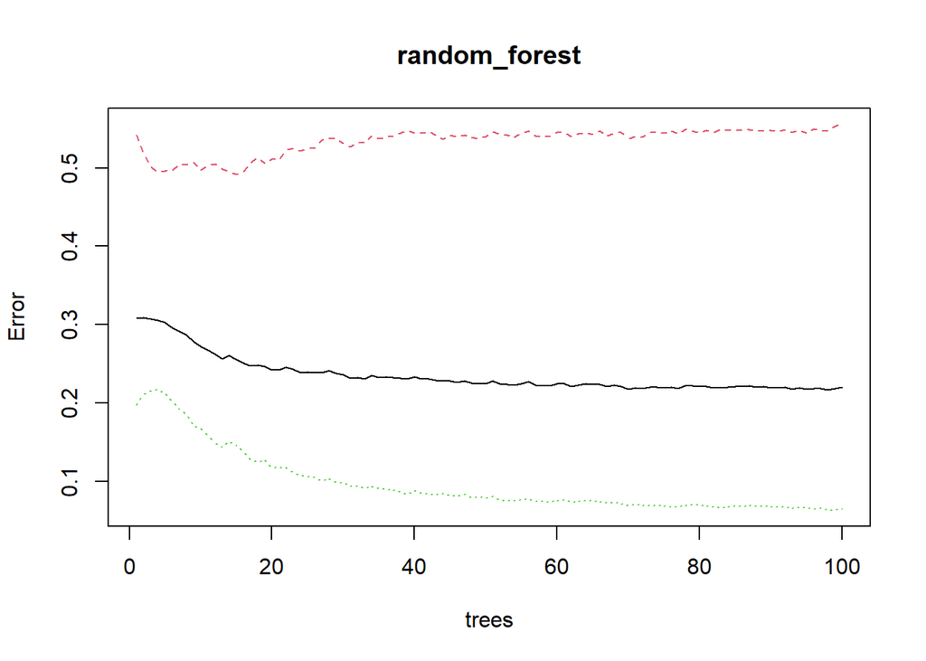

```r
plot( random_forest )
```

From the plot, we see that if the number of trees is higher than about 80, we will have a munimal error. Therefore, we will continue working with an algorithm with 100 trees.

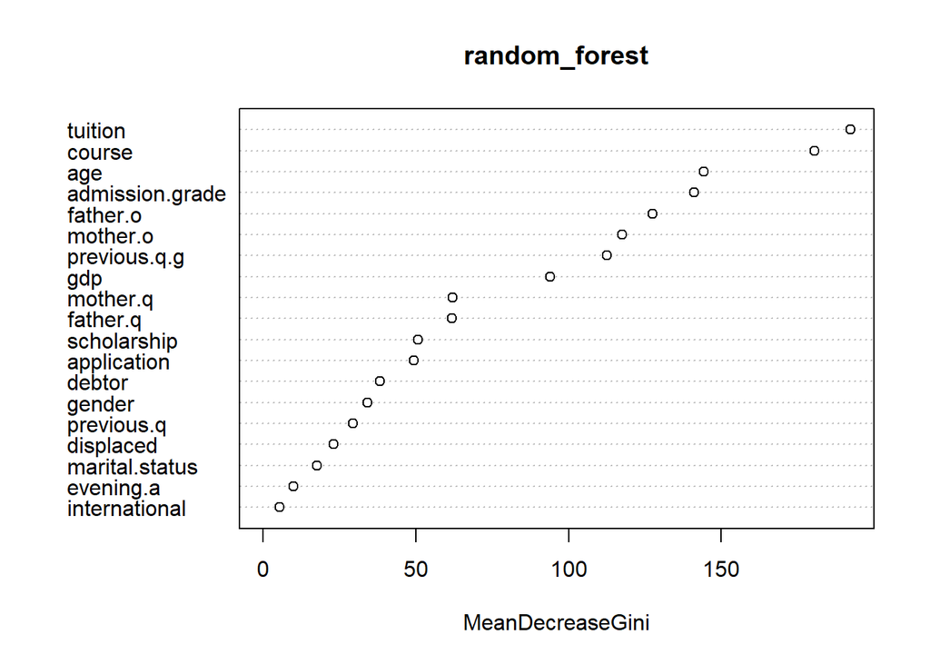

```r
random_forest = randomForest( formula = formula1, data = train_set1, ntree = 100 )

varImpPlot( random_forest )
```

We can see that the model chose `Tuition fees up to date` and `Course` as the most important variables and `Evening attendance` and `International` as the least important variables for predicting dropout.

## 5.4 Classification with Logistic Regression

The target variable `Target` in our dataset is binary. For our case, the binary logistic regression is the most suitable regression model to predict relationship between a binary target variable and a set of independent variables. By using logistic regression we would classify whether or not a student will dropout from the university.

For the Logistic Regression Model we use the same formula as in previous classification algorithms.

The following 19 predictors are used in the formula:

```r
formula = `Target` ~ `Marital status`+ `Course`+ `Previous qualification`+`Mother's qualification`+`Mother's occupation`+ `Father's qualification`+ `Father's occupation`+ `Displaced`+ `Debtor`+ `Tuition fees up to date`+ `Gender`+ `Scholarship holder`+ `Application order`+ `Evening attendance`+ `International`+ `Admission grade`+ `Previous qualification (grade)`+ `Age at enrollment`+ `GDP`
```

To implement the logistic regression model, we use the `glm()` command with “binomial” setting meaning it is returning binomial predictions of “Dropout” or “Stayed.enrolled”.

```r
reg_all = glm( formula = formula, family = "binomial", data = train_set )
summary(reg_all)
```

```
##
## Call:
## glm(formula = formula, family = "binomial", data = train_set)
##
## Coefficients:
##                                                 Estimate Std. Error z value
## (Intercept)                                    -3.020778   1.039558  -2.906
## `Marital status`Married                         0.574678   0.194340   2.957
## `Marital status`Divorced                        0.712610   0.349273   2.040
## `Marital status`Widowed                         0.124169   1.255392   0.099
## `Marital status`Facto.Union                     0.997778   0.620135   1.609
## `Marital status`Legally.Separated              -1.016121   1.131196  -0.898
## CourseTourism                                  -0.035664   0.253911  -0.140
## CourseCommunication Design                      0.814123   0.282156   2.885
## CourseJournalism and Communication              0.652397   0.253739   2.571
## CourseSocial Service                            1.087954   0.252009   4.317
## CourseManagement                                0.255594   0.228720   1.117
## CourseNursing                                   1.120889   0.229788   4.878
## CourseAdvertising and Marketing Management      0.514460   0.263148   1.955
## CourseBasic Education                          -0.353489   0.271625  -1.301
## CourseVeterinary Nursing                        0.900495   0.261156   3.448
## CourseEquinculture                             -0.550490   0.287449  -1.915
## CourseOral Hygiene                             -0.215740   0.357101  -0.604
## CourseAgronomy                                  0.905359   0.286431   3.161
## CourseBiofuel Production Technologies          -0.599828   0.802286  -0.748
## CourseInformatics Engineering                  -0.044348   0.273593  -0.162
## `Previous qualification`Higher(bachelor's)     -0.031428   0.675370  -0.047
## `Previous qualification`Secondary               0.755437   0.651238   1.160
## `Previous qualification`Specialized             0.730847   0.670270   1.090
## `Previous qualification`Basic                   0.266757   0.687377   0.388
## `Previous qualification`Other.or.Blank          0.729969   0.992120   0.736
## `Mother's qualification`Higher(bachelor's)     -0.204712   0.325410  -0.629
## `Mother's qualification`Secondary              -0.419146   0.326826  -1.282
## `Mother's qualification`Secondary(<10years)    -0.405975   0.328419  -1.236
## `Mother's qualification`Basic                  -0.454922   0.341217  -1.333
## `Mother's qualification`Vocational/Technical   -0.654207   0.727839  -0.899
## `Mother's qualification`Unknown/Incomplete     -0.073954   1.097901  -0.067
## `Mother's occupation`Science.Intermediate       0.332529   0.221698   1.500
## `Mother's occupation`Unskilled.Professions      0.199202   0.167041   1.193
## `Mother's occupation`Skilled.Professions       -0.180145   0.213311  -0.845
```

[output cut: 118 more lines]

```
## InternationalYes                              0.013152 *
## `Admission grade`                             1.01e-05 ***
## `Previous qualification (grade)`              0.043343 *
## `Age at enrollment`                           9.40e-10 ***
## GDP                                           0.001575 **
## ---
## Signif. codes:  0 '***' 0.001 '**' 0.01 '*' 0.05 '.' 0.1 ' ' 1
##
## (Dispersion parameter for binomial family taken to be 1)
##
##     Null deviance: 4403.5  on 3523  degrees of freedom
## Residual deviance: 3157.0  on 3446  degrees of freedom
## AIC: 3313
##
## Number of Fisher Scoring iterations: 13
```

`glm` regression function automatically splits categorical factors (with k categories) that are present in the formula into (k-1) dummy variables. It also sets first category of every categorical variable as a reference category. For instance, `Marital status` initially had 6 categories so the regression created and picked 5 dummy variables: `Marital status`Married , `Marital status`Divorced, `Marital status`Widowed, `Marital status`Facto.Union, and `Marital status`Legally.Separated.

We got a long list of different coefficients for the regression. Looking at the significance, dummy variables that were derived from the same categorical predictor have different significance levels. Some dummy variable’s coefficients are not significant at all, whereas, at the same time, other dummies are significant. We can only choose whether we should use the independent categorical variables as a whole or not. In other words, we should only see whether the categorical variable as a whole is significant or not. We cannot include some categories of a variable and exclude some categories having insignificant difference.

It is reasonable to exclude categorical variables from the regression which do not have any significant dummy. So we exclude `Previous qualification`, `Mother's qualification`, `Displaced`, `Application order`, `Evening attendance`

```r
formula_new = `Target` ~ `Marital status`+ `Course`+`Mother's occupation`+ `Father's qualification`+ `Father's occupation`+ `Debtor`+ `Tuition fees up to date`+ `Gender`+ `Scholarship holder`+ `International`+ `Admission grade`+ `Previous qualification (grade)`+ `Age at enrollment`+ `GDP`
```

```r
reg_some = glm( formula = formula_new, family = "binomial", data = train_set )
summary(reg_some)
```

```
##
## Call:
## glm(formula = formula_new, family = "binomial", data = train_set)
##
## Coefficients:
##                                                 Estimate Std. Error z value
## (Intercept)                                    -2.442889   0.680089  -3.592
## `Marital status`Married                         0.588405   0.192034   3.064
## `Marital status`Divorced                        0.716119   0.342229   2.093
## `Marital status`Widowed                         0.341873   1.268284   0.270
## `Marital status`Facto.Union                     0.854294   0.623266   1.371
## `Marital status`Legally.Separated              -0.825948   1.102935  -0.749
## CourseTourism                                  -0.071689   0.251713  -0.285
## CourseCommunication Design                      0.764995   0.277876   2.753
## CourseJournalism and Communication              0.593534   0.250468   2.370
## CourseSocial Service                            1.121657   0.240772   4.659
## CourseManagement                                0.280309   0.216267   1.296
## CourseNursing                                   0.993881   0.223764   4.442
## CourseAdvertising and Marketing Management      0.484027   0.259481   1.865
## CourseBasic Education                          -0.384310   0.268835  -1.430
## CourseVeterinary Nursing                        0.854666   0.255970   3.339
## CourseEquinculture                             -0.532599   0.282729  -1.884
## CourseOral Hygiene                             -0.321255   0.347835  -0.924
## CourseAgronomy                                  0.847855   0.277117   3.060
## CourseBiofuel Production Technologies          -0.587112   0.790205  -0.743
## CourseInformatics Engineering                  -0.111562   0.270330  -0.413
## `Mother's occupation`Science.Intermediate       0.376987   0.212322   1.776
## `Mother's occupation`Unskilled.Professions      0.186270   0.164576   1.132
## `Mother's occupation`Skilled.Professions       -0.187327   0.211964  -0.884
## `Mother's occupation`Administrative.Support     0.069951   0.170180   0.411
## `Mother's occupation`Public.Administration      0.064899   0.337778   0.192
## `Mother's occupation`Science.Specialist         0.323225   0.223779   1.444
## `Mother's occupation`Student                   -1.619063   0.403902  -4.009
## `Mother's occupation`Other.or.Blank            -1.102705   0.475655  -2.318
## `Mother's occupation`Manufacturing             -1.179382   0.426521  -2.765
## `Mother's occupation`Healthcare                12.209341 339.613977   0.036
## `Mother's occupation`Armed.Forces               0.272706   1.339693   0.204
## `Mother's occupation`Teacher                   -0.419113   1.017052  -0.412
## `Father's qualification`Higher(bachelor's)      0.486700   0.315431   1.543
## `Father's qualification`Secondary               0.438226   0.299011   1.466
```

[output cut: 82 more lines]

```
## InternationalYes                              0.008277 **
## `Admission grade`                             1.12e-05 ***
## `Previous qualification (grade)`              0.089109 .
## `Age at enrollment`                           6.43e-14 ***
## GDP                                           0.002238 **
## ---
## Signif. codes:  0 '***' 0.001 '**' 0.01 '*' 0.05 '.' 0.1 ' ' 1
##
## (Dispersion parameter for binomial family taken to be 1)
##
##     Null deviance: 4403.5  on 3523  degrees of freedom
## Residual deviance: 3180.5  on 3464  degrees of freedom
## AIC: 3300.5
##
## Number of Fisher Scoring iterations: 13
```

We can make decision about inclusion of the variables by checking a likelihood ratio test. It is performed by estimating two models and comparing the fit of one model to the fit of the other. Removing predictor variables from a model will almost always make the model fit less well but it is necessary to test whether the observed difference in model fit is statistically significant. It tests whether this difference is statistically significant.

```r
anova(reg_all, reg_some, test="LRT")
```

```
## Analysis of Deviance Table
##
## Model 1: Target ~ `Marital status` + Course + `Previous qualification` +
##     `Mother's qualification` + `Mother's occupation` + `Father's qualification` +
##     `Father's occupation` + Displaced + Debtor + `Tuition fees up to date` +
##     Gender + `Scholarship holder` + `Application order` + `Evening attendance` +
##     International + `Admission grade` + `Previous qualification (grade)` +
##     `Age at enrollment` + GDP
## Model 2: Target ~ `Marital status` + Course + `Mother's occupation` +
##     `Father's qualification` + `Father's occupation` + Debtor +
##     `Tuition fees up to date` + Gender + `Scholarship holder` +
##     International + `Admission grade` + `Previous qualification (grade)` +
##     `Age at enrollment` + GDP
##   Resid. Df Resid. Dev  Df Deviance Pr(>Chi)
## 1      3446     3157.0
## 2      3464     3180.5 -18   -23.51   0.1717
```

Since p-value is more than 0.05, it means the difference is insignificant and the variables `Previous qualification`, `Mother's qualification`, `Displaced`, `Application order`, and `Evening attendance` should be excluded from the model.

### 5.4.1 Verifying Model Assumptions

Before a regression model can be implemented, the requisite model assumptions must be verified. The assumptions for the Logistic Regression model are different from other regressions like Linear Regression model.

Assumptions for Logistic Regression model are:

> The outcome is a binary or dichotomous variable like yes vs no, positive vs negative, 1 vs 0. There is a linear relationship between the logit of the outcome and each predictor variables. There is no influential values (extreme values or outliers) in the continuous predictors. There is no high intercorrelations (i.e. multicollinearity) among the predictors.

First assumption is met because our dependent variable `Target` has only two outcomes `Dropout` and `Stayed.enrolled`.

Second assumption may be checked looking at the following plots containing numerical variables:

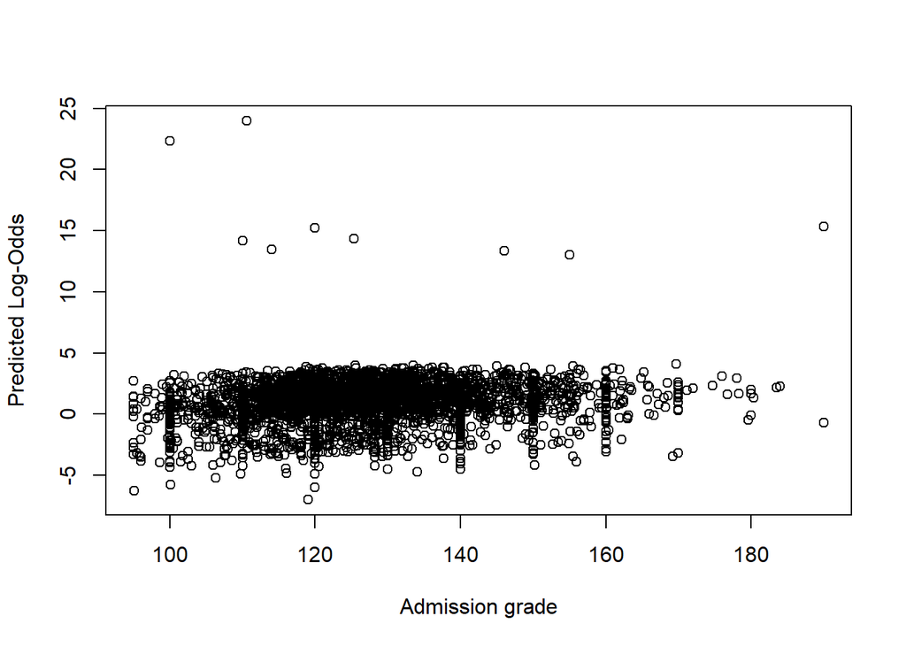

```r
predictions <- predict(reg_some, type = "link")
plot( train_set$`Admission grade`, predictions, xlab = "Admission grade", ylab = "Predicted Log-Odds")
```

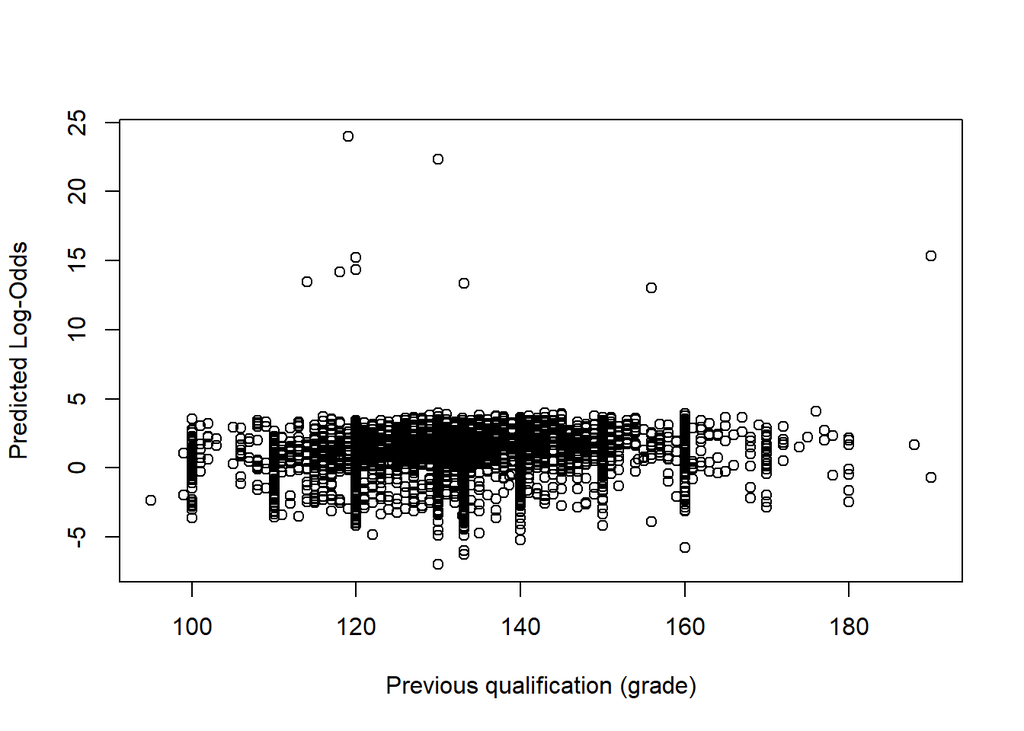

```r
plot( train_set$`Previous qualification (grade)`, predictions, xlab = "Previous qualification (grade)", ylab = "Predicted Log-Odds")
```

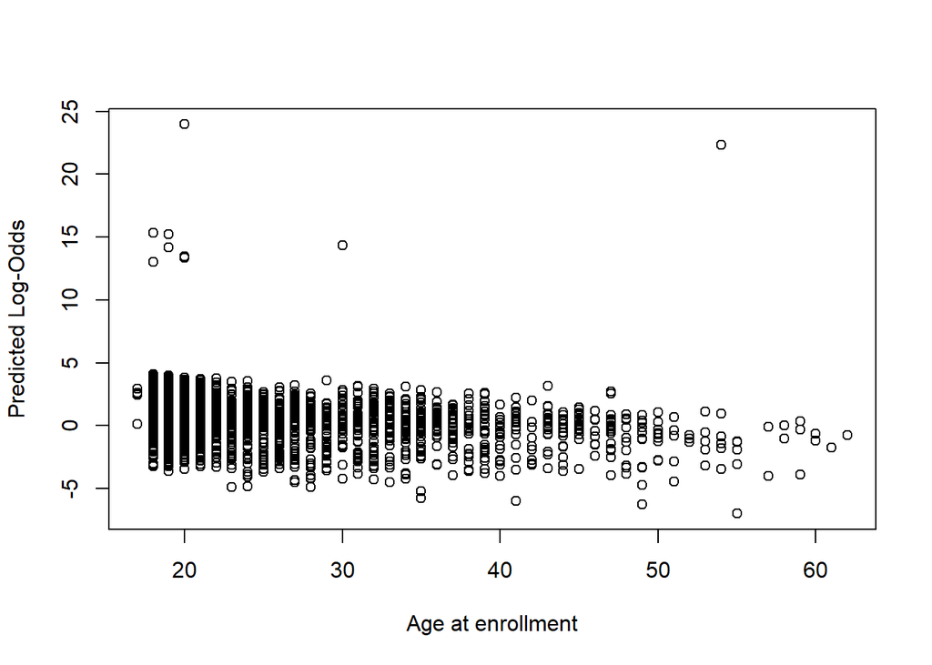

```r
plot( train_set$`Age at enrollment`, predictions, xlab = "Age at enrollment", ylab = "Predicted Log-Odds")
```

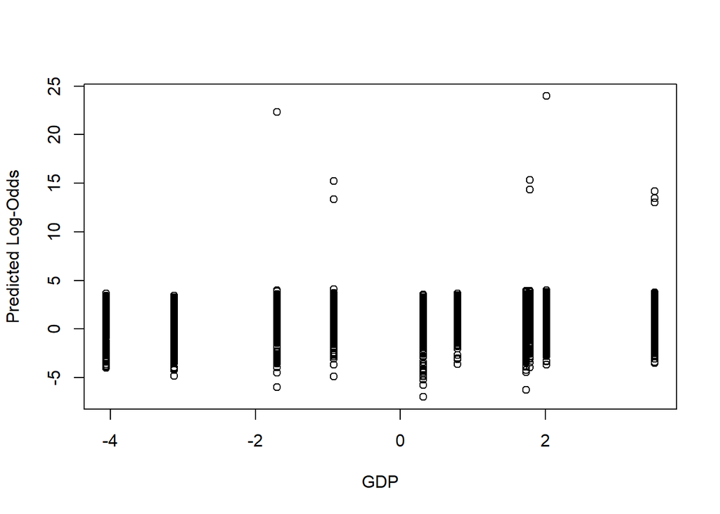

```r
plot( train_set$`GDP`, predictions, xlab = "GDP", ylab = "Predicted Log-Odds")
```

We can see that every numeric variable has linear realtionship with the logit of the outcome `Target` except variable `GDP`. For the assumption to be met we will exclude `GDP` from the final regression model.

Third assumption is done and fulfilled during `Outliers and Unusual values` section of the research.

Forth assumption is done and fulfilled during `Detection of Correlated Variables` section of the research.

So in the end we illuminate `GDP` predictor because it does not fit our model assumptions.

```r
formula_last = `Target` ~ `Marital status`+ `Course`+`Mother's occupation`+ `Father's qualification`+ `Father's occupation`+ `Debtor`+ `Tuition fees up to date`+ `Gender`+ `Scholarship holder`+ `International`+ `Admission grade`+ `Previous qualification (grade)`+ `Age at enrollment`
```

Here is our final Logistic Regression Model:

```r
log_reg = glm( formula = formula_last, family = "binomial", data = train_set )
summary(log_reg)
```

```
##
## Call:
## glm(formula = formula_last, family = "binomial", data = train_set)
##
## Coefficients:
##                                                 Estimate Std. Error z value
## (Intercept)                                    -2.386893   0.677657  -3.522
## `Marital status`Married                         0.557049   0.191256   2.913
## `Marital status`Divorced                        0.709238   0.340992   2.080
## `Marital status`Widowed                         0.389676   1.278642   0.305
## `Marital status`Facto.Union                     0.896536   0.618906   1.449
## `Marital status`Legally.Separated              -0.820415   1.089191  -0.753
## CourseTourism                                  -0.045199   0.250518  -0.180
## CourseCommunication Design                      0.755293   0.277384   2.723
## CourseJournalism and Communication              0.581365   0.249863   2.327
## CourseSocial Service                            1.128709   0.239813   4.707
## CourseManagement                                0.291893   0.215409   1.355
## CourseNursing                                   0.988102   0.223115   4.429
## CourseAdvertising and Marketing Management      0.487189   0.258105   1.888
## CourseBasic Education                          -0.389162   0.268622  -1.449
## CourseVeterinary Nursing                        0.870456   0.255484   3.407
## CourseEquinculture                             -0.529795   0.281898  -1.879
## CourseOral Hygiene                             -0.313688   0.348715  -0.900
## CourseAgronomy                                  0.792822   0.275010   2.883
## CourseBiofuel Production Technologies          -0.475293   0.788170  -0.603
## CourseInformatics Engineering                  -0.063377   0.268969  -0.236
## `Mother's occupation`Science.Intermediate       0.402968   0.212247   1.899
## `Mother's occupation`Unskilled.Professions      0.184120   0.164275   1.121
## `Mother's occupation`Skilled.Professions       -0.205447   0.211864  -0.970
## `Mother's occupation`Administrative.Support     0.074318   0.169953   0.437
## `Mother's occupation`Public.Administration      0.016940   0.337797   0.050
## `Mother's occupation`Science.Specialist         0.323769   0.223129   1.451
## `Mother's occupation`Student                   -1.639797   0.402187  -4.077
## `Mother's occupation`Other.or.Blank            -1.107414   0.474757  -2.333
## `Mother's occupation`Manufacturing             -1.146543   0.426892  -2.686
## `Mother's occupation`Healthcare                12.298744 343.170405   0.036
## `Mother's occupation`Armed.Forces               0.416429   1.331270   0.313
## `Mother's occupation`Teacher                   -0.287124   1.014661  -0.283
## `Father's qualification`Higher(bachelor's)      0.508712   0.314502   1.618
## `Father's qualification`Secondary               0.449731   0.298135   1.508
```

[output cut: 80 more lines]

```
## `Scholarship holder`Yes                        < 2e-16 ***
## InternationalYes                              0.006067 **
## `Admission grade`                             8.40e-06 ***
## `Previous qualification (grade)`              0.065969 .
## `Age at enrollment`                           5.60e-14 ***
## ---
## Signif. codes:  0 '***' 0.001 '**' 0.01 '*' 0.05 '.' 0.1 ' ' 1
##
## (Dispersion parameter for binomial family taken to be 1)
##
##     Null deviance: 4403.5  on 3523  degrees of freedom
## Residual deviance: 3189.8  on 3465  degrees of freedom
## AIC: 3307.8
##
## Number of Fisher Scoring iterations: 13
```

# 6 Model Evaluation

Based on our results, we will determine which classification algorithms is more suitable for the `dropout` database. To compare classification models we will use such comparison tools like:

- Confusion Matrix
- MSE
- ROC curve
- AUC (Area Under the ROC curve)

## 6.1 Confusion Matrix and MSE for CART

```r
tree_cart = rpart( formula = formula, data = train_set, method = "class" )
predict_cart = predict( tree_cart, test_set, type = "class" )
conf.mat( predict_cart, actual_test )
```

```
##                  Actual
## Predict           Dropout Stayed.enrolled
##   Dropout             140              32
##   Stayed.enrolled     163             565
```

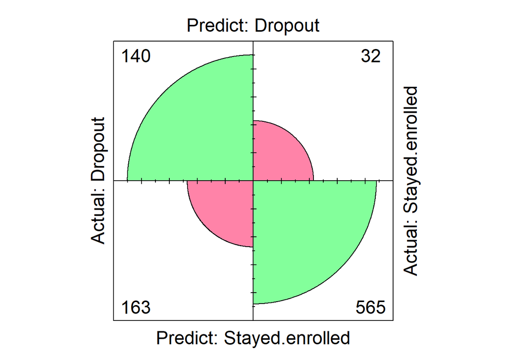

```r
conf.mat.plot( predict_cart, actual_test )
```

```r
print(paste0("MSE = ", mse( predict_cart, actual_test ) ))
```

```
## [1] "MSE = 0.216666666666667"
```

We observe that the model has “32 + 163 = 195” wrong predictions and mse 0.217.

## 6.2 Confusion Matrix and MSE for C50

```r
tree_C50 = C5.0( formula = formula, data = train_set, type = "class" )
predict_C50 = predict( tree_C50, test_set, type = "class" )
conf.mat( predict_C50, actual_test )
```

```
##                  Actual
## Predict           Dropout Stayed.enrolled
##   Dropout             142              35
##   Stayed.enrolled     161             562
```

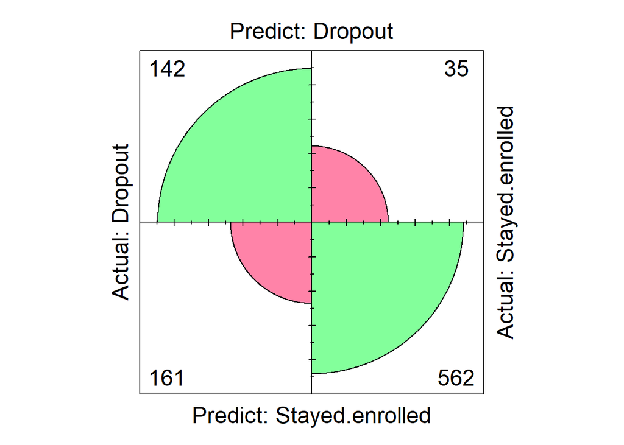

```r
conf.mat.plot( predict_C50, actual_test )
```

```r
print(paste0("MSE = ", mse( predict_C50, actual_test ) ))
```

```
## [1] "MSE = 0.217777777777778"
```

We observe that the model has “35 + 161 = 196” wrong predictions and mse 0.218.

The error rate is slightly higher than in the CART model.

## 6.3 Confusion Matrix and MSE for Random forest

```r
predict_random_forest = predict( random_forest, test_set1 )
conf.mat( predict_random_forest, actual_test1 )
```

```
##                  Actual
## Predict           Dropout Stayed.enrolled
##   Dropout             144              37
##   Stayed.enrolled     159             560
```

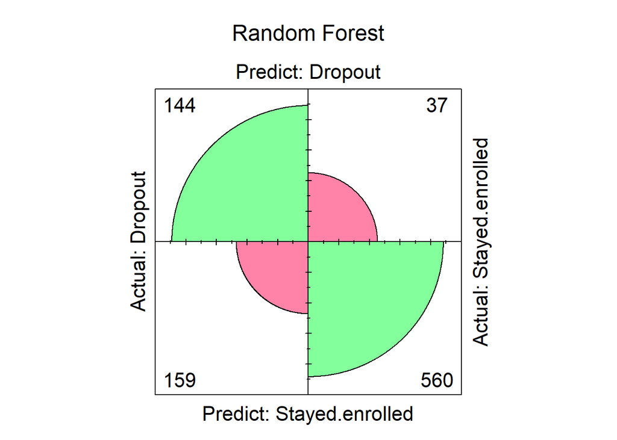

```r
conf.mat.plot( predict_random_forest, actual_test1, main = "Random Forest" )
```

```r
print(paste0("MSE = ", mse( predict_random_forest, actual_test1 )))
```

```
## [1] "MSE = 0.217777777777778"
```

We observe that the model has 37 + 159 = 196” wrong predictions and mse 0.218

## 6.4 Confusion Matrix and MSE for Logistic Regression

```r
predict_logreg = predict( log_reg, test_set )
cf_logreg = conf.mat( as.numeric(predict_logreg>0.5), actual_test )
cf_logreg
```

```
##        Actual
## Predict Dropout Stayed.enrolled
##       0     185             105
##       1     118             492
```

```r
print(paste0("MSE = ", mse( as.numeric(predict_logreg>0.5), actual_test )  ))
```

```
## [1] "MSE = 1.21888888888889"
```

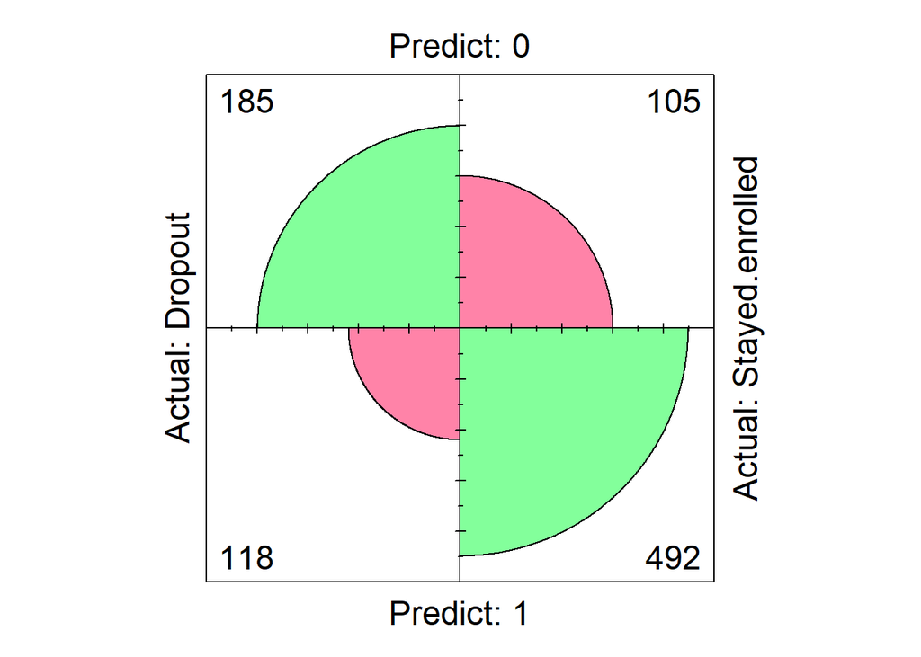

```r
conf.mat.plot( as.numeric(predict_logreg>0.5), actual_test )
```

We observe that the model has “105 + 118 = 223” wrong predictions and mse 1.219

## 6.5 ROC curve

To visualize the model performance between the classification algorithms, we report the ROC curve plot as well as AUC (Area Under the Curve):

[figure not shown]

```r
prob_cart = predict( tree_cart, test_set, type = "prob" )[ , 1 ]
roc_cart = roc( actual_test, prob_cart )

prob_C50 = predict( tree_C50, test_set, type = "prob" )[ , 1 ]
roc_C50 = roc( actual_test, prob_C50 )

prob_random_forest = predict( random_forest, test_set1, type = "prob" )[ , 1 ]
roc_random_forest = roc( actual_test1, prob_random_forest )

prob_logreg = predict( log_reg, test_set , type = "response")
roc_prob_reg = roc(actual_test, prob_logreg)


ggroc( list( roc_cart, roc_C50, roc_random_forest, roc_prob_reg ), size = 0.8 ) +
    theme_minimal() + ggtitle( "ROC plots with AUC for 4 outcomes") +
  scale_color_manual( values = 5:10,
    labels = c( paste( "Regression; AUC=", round( auc( roc_prob_reg ), 3 ) ) ,
                paste( "CART; AUC=", round( auc(  roc_C50 ), 3 ) ),
                paste( "C50; AUC=", round( auc( roc_cart ), 3 ) ),
                paste( "Random Forest; AUC=", round( auc( roc_random_forest ), 3 ) ) ) ) +
  theme( legend.title = element_blank() ) +
  theme( legend.position = c( .7, .3 ), text = element_text( size = 17 ) )
```

# 7 Conclusion

To make a conclusion about the model that is the most efficient for predicting whether a student will dropout or stay enrolled we will first look at the error rates of each model:

- **CART algorithm** has MSE = 0.217 ,
- **C5.0 algorithm** has MSE = 0.218 ,
- **Random Forest algorithm** has MSE = 0.218 ,
- **Logistic Regression** has MSE = 1.219.

Our initial goal was to determine the set of factors that influence the student’s decision the most. Those sets of factors were the student’s family history with higher education institutions and the social class background of the student, the student’s characteristics as well as factors that determine the state of the economy at the time when a specific response was collected.

With the use of the classification models, we derived that the possibility of a dropout can be approached early on during the admission process. The fact that the most powerful predictor of students’ dropout is the payment of the tuition is very intuitive, as those students, who are planning on dropping out will not prepay their tuition in advance. One of the key determinants was the course that the student is applying to, as some courses are a lot more academically challenging than others. Additionally, the age of enrollment has high predictive power, these finding suggests that the university’s administration should acknowledge the difficulties that might incentivize older students to drop out. For example, the difficulty to establish social relations with people, who are a lot younger than themselves. The fact that the previous grades and admission grades have a high impact on the student’s choice to drop out is also very intuitive, as it suggests whether the student can have high performance in an academically rigorous environment. Our findings also imply that the choice to drop out is highly related to the student’s social background (Father’s and Mother’s occupation). Surprisingly, we do not have enough statistical evidence that the student’s choice to drop out is related to the state of the economy, the student is experiencing, although economic theories suggest that, for example, high unemployment rates would incentivize people to stay in the universities. However, we have not found any association between the unemployment rate and inflation rate with dropout. The GDP showed some association with the target variable, however, it was not classified very high on the importance of predicting dropout.

Our research suggests that further research focuses more on the social background of the student and personal academic achievements rather than economic-wide trends in the country when predicting the chance of a particular person dropping out.

# 8 Reference List

Beaulac, C. & Rosenthal, J.S.(2019). Predicting university Students? academic success and major using random forests. Res. High. Educ. 60, 1048?1064. https://doi.org/10.1007/s11162-019-09546-y

Dobson, A., & Henderson, R. (2003). Diagnostics for Joint Longitudinal and Dropout Time Modeling. Biometrics, 59(4), 741-751. https://doi.org/10.1111/j.0006-341X.2003.00087.x

Kehm, B. M., Larsen, M. R., & Sommersel, H. B. (2019). Student dropout from universities in Europe: A review of empirical literature. Hungarian Educational Research Journal, 9(2), 147-164. https://doi.org/10.1556/063.9.2019.1.18

Migueis, V.L., Freitas, A., Garcia, P.J.V., Silva, A.: Early segmentation of students according to their academic performance: a predictive modelling approach. Decis. Support Syst. 115, 36’51 (2018). https://doi.org/10.1016/j.dss.2018.09.001

Ortiz, A & Dehon, C.(September,2013). Roads to Success in the Belgian French Community?s Higher Education System: Predictors of Dropout and Degree Completion at the Universite Libre de Bruxelles. Res High Educ, 54, 693?723. https://doi.org/10.1007/s11162-013-9290-y

Sosu, E. M. & Pheunpha, P. (2019). Trajectory of University Dropout: Investigating the Cumulative Effect of Academic Vulnerability and Proximity to Family Support. Frontiers in Education, 4, 409050. https://doi.org/10.3389/feduc.2019.00006